# Heart Disease Analysis

Tianchen He

2024-11-17

## Introduction

This report analyzes a heart disease dataset obtained from Kaggle. The dataset contains 14 medical and demographic variables related to the presence or absence of heart disease. These variables include factors such as age, sex, chest pain type, resting blood pressure, cholesterol levels, and other health indicators.

The objective of this analysis is to explore key characteristics of the dataset and identify trends or factors contributing to the diagnosis of heart disease. The insights from this analysis will inform future predictive modeling.

## Data Loading

We first load the dataset and explore its structure.

```
## 'data.frame':    1025 obs. of  14 variables:
##  $ age     : int  52 53 70 61 62 58 58 55 46 54 ...
##  $ sex     : int  1 1 1 1 0 0 1 1 1 1 ...
##  $ cp      : int  0 0 0 0 0 0 0 0 0 0 ...
##  $ trestbps: int  125 140 145 148 138 100 114 160 120 122 ...
##  $ chol    : int  212 203 174 203 294 248 318 289 249 286 ...
##  $ fbs     : int  0 1 0 0 1 0 0 0 0 0 ...
##  $ restecg : int  1 0 1 1 1 0 2 0 0 0 ...
##  $ thalach : int  168 155 125 161 106 122 140 145 144 116 ...
##  $ exang   : int  0 1 1 0 0 0 0 1 0 1 ...
##  $ oldpeak : num  1 3.1 2.6 0 1.9 1 4.4 0.8 0.8 3.2 ...
##  $ slope   : int  2 0 0 2 1 1 0 1 2 1 ...
##  $ ca      : int  2 0 0 1 3 0 3 1 0 2 ...
##  $ thal    : int  3 3 3 3 2 2 1 3 3 2 ...
##  $ target  : int  0 0 0 0 0 1 0 0 0 0 ...
```

## Table: Descriptive Statistics for Age and Sex

The table below summarizes key statistics for the variables age and sex.

```r
# Source the tables script
source(here("src/tables.R"))
```

```
## here() starts at /project
```

```r
# Load the generated table
age_sex_stats <- readRDS(here("output/age_sex_stats.rds"))

# Display the table
knitr::kable(age_sex_stats, caption = "Descriptive Statistics for Age and Sex")
```

Descriptive Statistics for Age and Sex

| age_mean | age_sd | sex_mean | sex_sd |
| --- | --- | --- | --- |
| 54.43415 | 9.07229 | 0.6956098 | 0.4603733 |

## Figure: Distribution of Resting Blood Pressure

```r
# Source the figures script
source(here("src/figures.R"))
```

```
## here() starts at /project
```

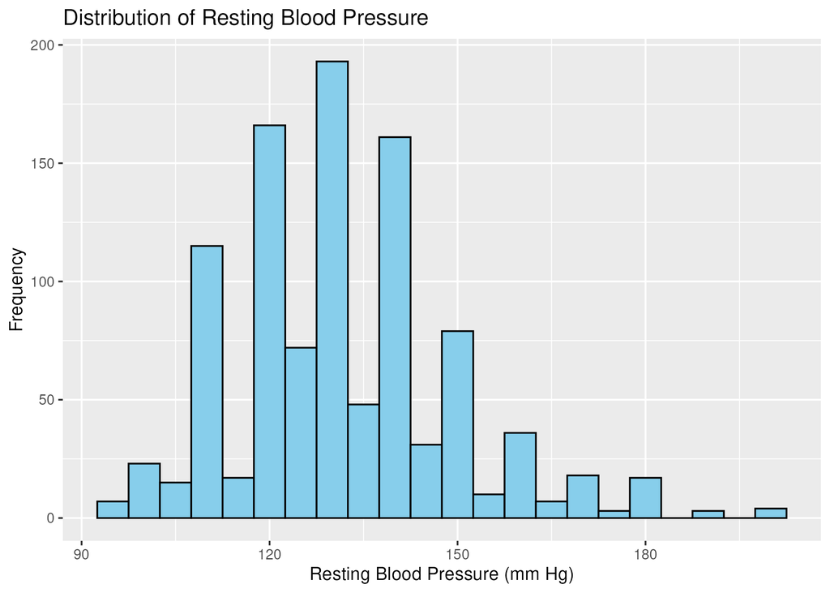

```r
# Display the pre-saved plot
knitr::include_graphics(here("output/bp_plot.png"))
```

The histogram indicates that most patients have a resting blood pressure between 120 and 140 mm Hg, though some patients exhibit much higher values, suggesting potential hypertension.

## Conclusion

This report provides an overview of the heart disease dataset, exploring variables such as age, sex, and resting blood pressure. The descriptive statistics and visualizations highlight key trends and risk factors, paving the way for predictive modeling.